# Выявление закономерностей, определяющих успешность компьютерных игр для интернет-магазина.

### Определение актуального периода

Исходя из количества выпущенных игр по годам и количества оценок и рейтинга по годам, исследованных на предыдущих этапах, определим актуальный период как 2012-2016 годы. Это период максимально близкий к 2017 году, значит можно предположить что тенденции этих лет сохранятся на 2017 год.

```python
# Создание таблицы на основе среза, проверка частоты значений в датасете.
df_good = df.query('year_of_release >= 2012')
df_good['year_of_release'].value_counts()
```

```
2012    652
2015    606
2014    581
2013    544
2016    502
Name: year_of_release, dtype: int64
```

### Динамика продаж по платформам в актуальном периоде

Посмотрим какие платформы лидируют по продажам, растут или падают.

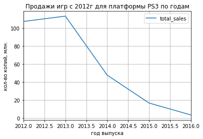

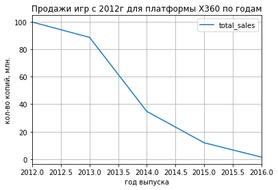

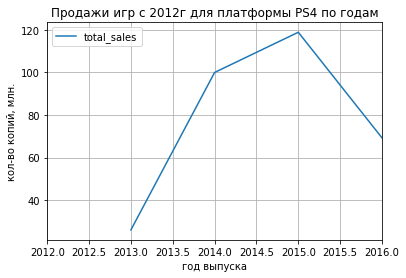

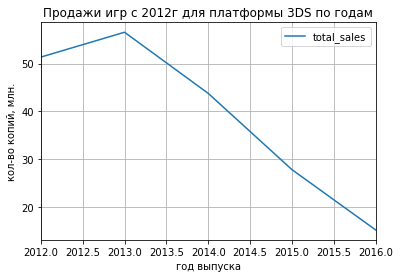

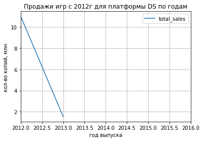

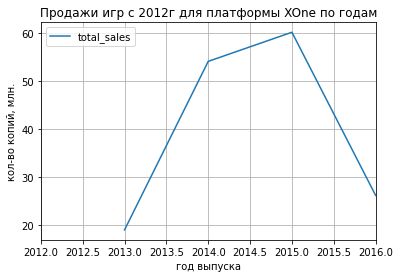

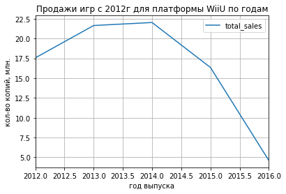

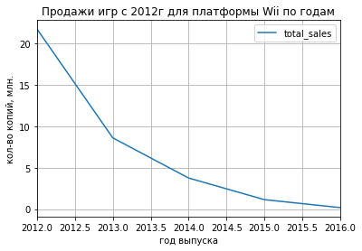

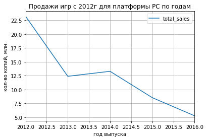

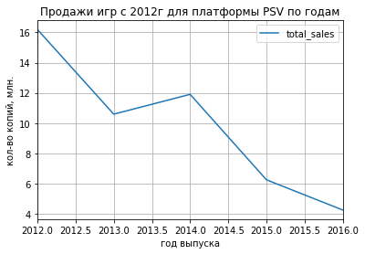

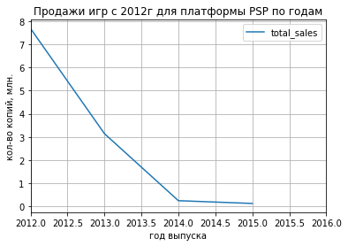

```python
# Вывод графиков в цикле
for platf in df_good['platform'].unique():
    df_good.query('platform == @platf').pivot_table(index='year_of_release', values='total_sales',
                aggfunc='sum').plot(xlim = (2012, 2016), xlabel='год выпуска', ylabel='кол-во копий, млн.',
                title='Продажи игр с 2012г для платформы '+platf+ " по годам", grid=True)
```

#### Выводы

В актуальном периоде (2012-2016 годы) присутствуют данные для 11-ти платформ.

Очевидный рост продаж наблюдается только для двух из них: XOne и PS4 - до 60 и до 120 млн копий в год соответственно.

Падение продаж почти до нуля произошло для платформ: PSP, Wii, DS, X360, PS3.

### График «ящик с усами» в разбивке по платформам

Построим график «ящик с усами» по глобальным продажам игр в разбивке по платформам, отражающий количество годовых продаж.

```
Годовые количества продаж по платформам
```

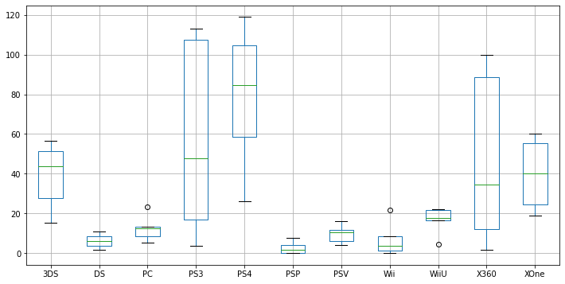

```python
# boxplot
print('Годовые количества продаж по платформам')
df_good.pivot_table(index='year_of_release',columns='platform', values='total_sales',
                    aggfunc='sum').boxplot(figsize=(12,6));
```

Построим график «ящик с усами» по глобальным продажам игр в разбивке по платформам, отражающий количество продаж по одной игре.

```
Количества продаж одной игры по платформам
```

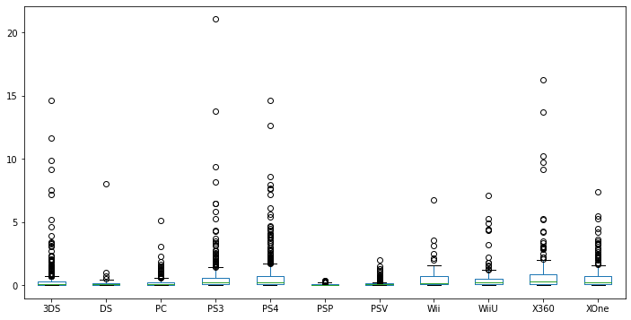

```python
# boxplot
print('Количества продаж одной игры по платформам')

df_good.pivot_table(index='name',columns='platform', values='total_sales', aggfunc='sum').plot.box(figsize=(12,6));
```

Выведем предыдущую диаграмму в диапазоне оси Y от 0 до 1 чтобы показать медиану и квартили.

```
Количества продаж одной игры по платформам (диапазон оси Y  от 0 до 1)
```

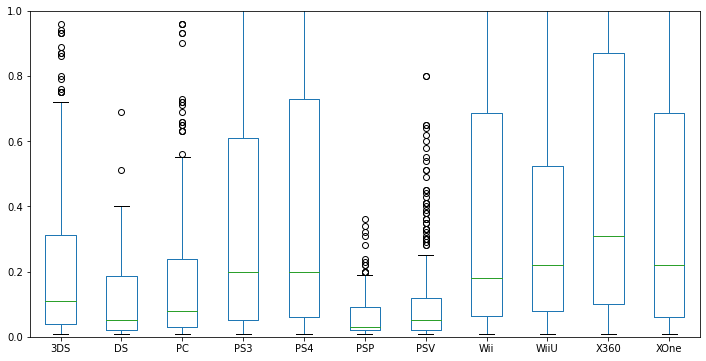

```python
# boxplot
print('Количества продаж одной игры по платформам (диапазон оси Y  от 0 до 1)')

df_good.pivot_table(index='name',columns='platform', values='total_sales', aggfunc='sum').plot.box(ylim=(0,1), figsize=(12,6));
```

#### Выводы

Продажи для платформ X360 и PS3 с течением лет возрастали или уменьшались в несколько раз, от 20 до 120 млн копий в год, тогда как для большинтсва платформ этот диапазон в течение лет составлял нескольких млн копий.

Почти для всех платформ были выпущены такие игры, количество продаж которых предсавлет собой очень большие выбросы. Это игры- "хиты". Самое большое количество копий одной игры - более 20 млн мы видим для платформы PS3.

### Корреляция между отзывами и продажами платформы PS4.

Посмотрим, как влияют на продажи внутри одной популярной платформы отзывы пользователей и критиков. Построим диаграмму рассеяния и посчитаем корреляцию между отзывами и продажами. Возьмем платформу PS4.

```python
# корреляция с заглушкой
df_ps4 = df_good.query('platform=="PS4" and user_score != -1 and critic_score != -1')[['total_sales',
                                                                                       'critic_score', 'user_score']]
```

```python
# Коэффициент корреляции Пирсона между всеми парами столбцов
df_ps4.corr()
```

|  | total_sales | critic_score | user_score |
| --- | --- | --- | --- |
| total_sales | 1.000000 | 0.405895 | -0.033625 |
| critic_score | 0.405895 | 1.000000 | 0.557654 |
| user_score | -0.033625 | 0.557654 | 1.000000 |

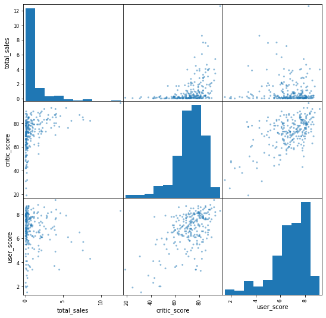

```python
# Попарные диаграммы рассеяния для всех столбцов датафрейма
pd.plotting.scatter_matrix(df_ps4, figsize=(9, 9));
```

#### Выводы

Коэффициент Пирсона 0.56 между оценками критиков и оценками пользователей говорит о том что между этими данными есть линейная взаимосвязь средней силы. Но мы не можем точно сказать, это оценки критиков влияют на оценки пользователей или наоборот.

### Корреляция между отзывами и продажами других платформ.

Посмотрим, как влияют на продажи внутри других платфом отзывы пользователей и критиков. Построим диаграмму рассеяния и посчитаем корреляцию между отзывами и продажами.

```python
# Создание таблицы на основе среза
df_other_patforms = df_good.query('platform!="PS4" and user_score != -1 and critic_score != -1')[['total_sales',
                                                                    'critic_score', 'user_score']]
```

```python
# Коэффициент корреляции Пирсона между всеми парами столбцов
df_other_patforms.corr()
```

|  | total_sales | critic_score | user_score |
| --- | --- | --- | --- |
| total_sales | 1.000000 | 0.283328 | 0.009352 |
| critic_score | 0.283328 | 1.000000 | 0.509484 |
| user_score | 0.009352 | 0.509484 | 1.000000 |

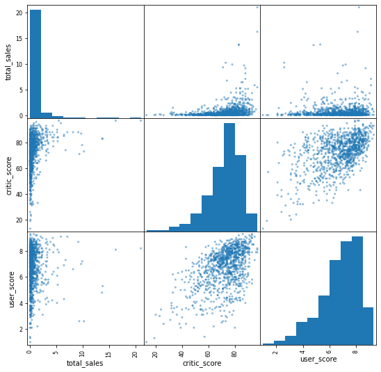

```python
# Попарные диаграммы рассеяния для всех столбцов датафрейма
pd.plotting.scatter_matrix(df_other_patforms, figsize=(9,9));
```

#### Выводы

Коэффициент Пирсона 0.51 между оценками критиков и оценками пользователей говорит о том что между этими данными есть линейная взаимосвязь средней силы. Но мы не можем точно сказать, это оценки критиков влияют на оценки пользователей или наоборот.

Линейную взаимосвязь между оценками пользователей или критиков и продажами установить не удалось. Выводы о корреляции сходятся с выводами на основе данных по платформе PS4.

### Продажи по жанрам

Посмотрим на общее распределение продаж игр по жанрам.

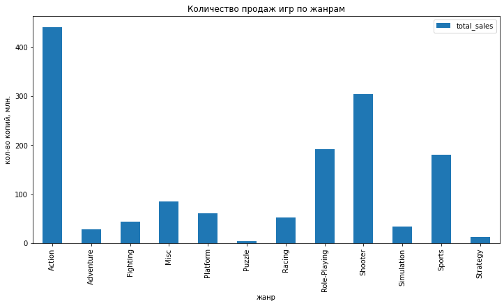

```python
# Столбчатая диаграмма по сводной таблице
df_good.pivot_table(index='genre', values='total_sales', aggfunc='sum').plot(kind='bar', figsize=(12,6),
                                xlabel='жанр', ylabel='кол-во копий, млн.', title='Количество продаж игр по жанрам');
```

Найдем количество продаж на одну игру по жанрам (в тысячах проданных копий)

```python
# Группировка сумм по значению
df_genre_sum = df_good.groupby('genre')['total_sales'].agg('sum')
```

```python
# Срез, удаление дубликатов, группировка количетва по значению
df_genre_count = df_good[['genre','name']].drop_duplicates().groupby('genre')['name'].agg('count')
```

```python
# Деление Series, сортировка по убыванию
(df_genre_sum*1000/df_genre_count).sort_values(ascending=False)
```

```
genre
Shooter         3207.684211
Sports          1828.888889
Platform        1326.086957
Racing          1114.583333
Action           768.501742
Fighting         729.344262
Role-Playing     727.547170
Misc             654.153846
Simulation       575.737705
Strategy         247.037037
Puzzle           212.608696
Adventure        136.250000
dtype: float64
```

#### Выводы

Однозначный лидер по количеству продаж на одну игру - жанр Shooter (более 3 млн продаж).

Так же популярны жанры Sports, Platform, Racing (от 1 до 2 млн продаж на одну игру).

Самый не популярный жанр - Adventure (136 тысяч продаж на одну игру)

По общему количеству продаж лидирует жанр Action (более 400 млн продаж)

Меньше всего продавались игры жанра Puzzle (менее 10 млн продаж)

### TOP-5 платформ по регионам

Для пользователя каждого региона (NA, EU, JP) определим самые популярные платформы (топ-5)

```python
# Группировка сумм по значению
df_region_platform = df_good.groupby('platform').agg({'na_sales':'sum','eu_sales':'sum','jp_sales':'sum'});
```

TOP-5 игровых платформ Северной Америки и доля их продаж

```python
# Срез, сортирока по убыванию, вывод верхних строк
df_region_platform['na_sales'].sort_values(ascending=False).head(5)
```

```
platform
X360    140.05
PS4     108.74
PS3     103.38
XOne     93.12
3DS      55.31
Name: na_sales, dtype: float64
```

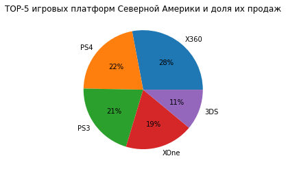

```python
# Круговая диаграмма
df_region_platform['na_sales'].sort_values(ascending=False).head(5).plot(kind='pie', ylabel='', autopct="%.f%%",
                                        title='TOP-5 игровых платформ Северной Америки и доля их продаж');
```

TOP-5 игровых платформ Европы и доля их продаж

```python
# Срез, сортирока по убыванию, вывод верхних строк
df_region_platform['eu_sales'].sort_values(ascending=False).head(5)
```

```
platform
PS4     141.09
PS3     106.85
X360     74.52
XOne     51.59
3DS      42.64
Name: eu_sales, dtype: float64
```

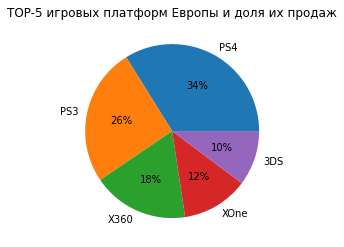

```python
# Круговая диаграмма
df_region_platform['eu_sales'].sort_values(ascending=False).head(5).plot(kind='pie',  ylabel='', autopct="%.f%%",
                                            title='TOP-5 игровых платформ Европы и доля их продаж');
```

TOP-5 игровых платформ Японии и доля их продаж

```python
# Срез, сортирока по убыванию, вывод верхних строк
df_region_platform['jp_sales'].sort_values(ascending=False).head(5)
```

```
platform
3DS     87.79
PS3     35.29
PSV     21.04
PS4     15.96
WiiU    13.01
Name: jp_sales, dtype: float64
```

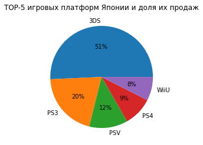

```python
# Круговая диаграмма
df_region_platform['jp_sales'].sort_values(ascending=False).head(5).plot(kind='pie', ylabel='', autopct="%.f%%",
                                            title='TOP-5 игровых платформ Японии и доля их продаж');
```

#### Выводы

Игровая платформа PS3 входит в тройку лидеров во всех регионах. Популярность платформ в Северной Америке и Европе схожа, только платформа X360 лидирует в Северной Америке, а в Европе она на третьем месте. В Европе лидирует PS4. Популярность платформ в Японии сильно отличается, здесь лидирует и занимает половину всех продаж TOP-5 платформа 3DS, которая в Америке и Европе находится на последнем месте в TOP-5.

### TOP-5 жанров по регионам

Для пользователя каждого региона (NA, EU, JP) определим самые популярные жанры (топ-5)

```python
# Группировка сумм по значению
df_region_genre = df_good.groupby('genre').agg({'na_sales':'sum','eu_sales':'sum','jp_sales':'sum'}).reset_index();
```

TOP-5 игровых жанров Северной Америки

```python
# Срез, сортирока по убыванию, вывод верхних строк
df_region_genre[['genre', 'na_sales']].sort_values('na_sales', ascending=False).head(5)
```

|  | genre | na_sales |
| --- | --- | --- |
| 0 | Action | 177.84 |
| 8 | Shooter | 144.77 |
| 10 | Sports | 81.53 |
| 7 | Role-Playing | 64.00 |
| 3 | Misc | 38.19 |

TOP-5 игровых жанров Европы

```python
# Срез, сортирока по убыванию, вывод верхних строк
df_region_genre[['genre', 'eu_sales']].sort_values('eu_sales', ascending=False).head(5)
```

|  | genre | eu_sales |
| --- | --- | --- |
| 0 | Action | 159.34 |
| 8 | Shooter | 113.47 |
| 10 | Sports | 69.08 |
| 7 | Role-Playing | 48.53 |
| 6 | Racing | 27.29 |

TOP-5 игровых жанров Японии

```python
# Срез, сортирока по убыванию, вывод верхних строк
df_region_genre[['genre', 'jp_sales']].sort_values('jp_sales', ascending=False).head(5)
```

|  | genre | jp_sales |
| --- | --- | --- |
| 7 | Role-Playing | 65.44 |
| 0 | Action | 52.80 |
| 3 | Misc | 12.86 |
| 9 | Simulation | 10.41 |
| 2 | Fighting | 9.44 |

#### Выводы

Популярность игровых жанров в Северной Америке и Европе почти одинакова (лидирует Action), а от Японии сильно отличается. Жанр Role-Playing в Японии стоит на первом месте по популярности, а в Америке и Европе он только на четвертом. Разница в популярности жанров объясняется разницей культур востока и запада.

### Влияение рейтинга ESRB на продажи в отдельном регионе

Entertainment Software Rating Board (ESRB) — негосударственная организация, основное направление деятельности — принятие и определение рейтингов для компьютерных видеоигр и другого развлекательного программного обеспечения в США и Канаде.

«E» («Everyone») — «Для всех»: Содержание вполне подходит для возрастной категории от 6 лет. Такие игры могут понравиться и взрослым. Игры с этим рейтингом могут содержать минимальное насилие, в основном «мультяшного» характера.

«E10+» («Everyone 10 and older») — «Для всех от 10 лет и старше»: Проекты с данным рейтингом могут содержать или немного больше мультипликационного или мягкого насилия, или несколько откровенные сцены, или минимальное количество крови.

«T» («Teen») — «Подросткам»: Игра подходит для лиц от 13 лет. Проекты из данной категории могут содержать насилие, непристойные сцены, грубый юмор, в меру откровенное сексуальное содержимое, кровь или нечастое использование ненормативной лексики.

«M» («Mature») — «Для взрослых»: Материалы игры не подходят для подростков младше 17 лет. Проекты с данным рейтингом могут содержать достаточно жестокое насилие, большое количество крови с расчленением, непристойные сексуальные сцены или грубую ненормативную лексику, нежелательную для младшей аудитории.

```python
# Группировка сумм по значению
df_region_rating = df_good.groupby('rating').agg({'na_sales':'sum','eu_sales':'sum','jp_sales':'sum'});
```

Для пользователя каждого региона (NA, EU, JP) покажем количество продаж по рейтингу

```python
#Вывод отсортированной таблицы
display(df_region_rating.sort_values('na_sales', ascending=False))
```

| rating | na_sales | eu_sales | jp_sales |
| --- | --- | --- | --- |
| M | 231.57 | 193.96 | 21.20 |
| E | 114.37 | 113.02 | 28.33 |
| E10+ | 75.70 | 55.37 | 8.19 |
| T | 66.02 | 52.96 | 26.02 |

Доля продаж игр по рейтингу ESRB в Северной Америке

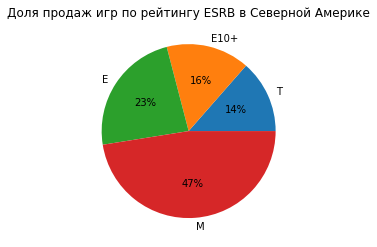

```python
# Круговая диаграмма
df_region_rating['na_sales'].sort_values().plot(kind='pie', ylabel='', autopct="%.f%%",
                                            title='Доля продаж игр по рейтингу ESRB в Северной Америке');
```

Доля продаж игр по рейтингу ESRB в Европе

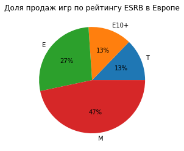

```python
# Круговая диаграмма
df_region_rating['eu_sales'].sort_values().plot(kind='pie', ylabel='', autopct="%.f%%",
                                            title='Доля продаж игр по рейтингу ESRB в Европе');
```

Доля продаж игр по рейтингу ESRB в Японии

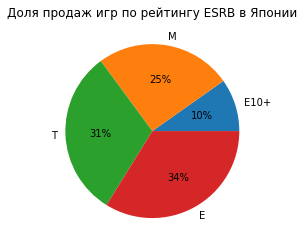

```python
# Круговая диаграмма
df_region_rating['jp_sales'].sort_values().plot(kind='pie', ylabel='', autopct="%.f%%",
                                            title='Доля продаж игр по рейтингу ESRB в Японии');
```

#### Выводы

Распределение продаж по рейтингу ESRB в Северной Америке и Европе схоже. Преобладают продажи игр с рейтингом «M» («Mature») — «Для взрослых». Они составляют почти половину всех продаж. Второе место занимают игры с рейтингом «E» («Everyone») — «Для всех». В Японии продажи игр с рейтингом «M» составляют только четвертую часть, на первом и втором месте по продажам игры с рейтингами «E» и «T» («Teen») — «Подросткам».

## Проверка гипотез

### Гипотеза: Средние пользовательские рейтинги платформ Xbox One и PC одинаковы

Общие характеристики пользовательских рейтингов платформы Xbox One:

```python
df_XOne = df_good.query('platform=="XOne" and user_score != -1 and critic_score != -1')['user_score']
df_XOne.describe()
```

```
count    165.000000
mean       6.538182
std        1.340298
min        2.100000
25%        5.800000
50%        6.800000
75%        7.500000
max        9.200000
Name: user_score, dtype: float64
```

Общие характеристики пользовательских рейтингов платформы PC:

```python
df_PC = df_good.query('platform=="PC" and user_score != -1 and critic_score != -1')['user_score']
df_PC.describe()
```

```
count    197.000000
mean       6.454315
std        1.639451
min        1.400000
25%        5.500000
50%        6.800000
75%        7.700000
max        9.300000
Name: user_score, dtype: float64
```

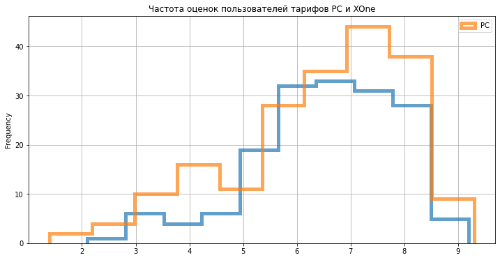

```python
# Гистограмма
ax = df_XOne.plot(kind='hist', y='user_score', histtype='step', bins=10, linewidth=5, alpha=0.7, label='XOne')
df_PC.plot(kind='hist', y='user_score', histtype='step', bins=10, linewidth=5, alpha=0.7, label='PC',
           ax=ax, grid=True, legend=True, figsize=(12,6), title='Частота оценок пользователей тарифов PC и XOne');
```

Нулевая гипотеза: Средние пользовательские рейтинги платформ Xbox One и PC одинаковы.

Альтернативная гипотеза: Средние пользовательские рейтинги платформ Xbox One и PC различны (больше или меньше).

Зададим критический уровень статистической значимости 5%, если p-value окажется меньше него - отвергнем гипотезу. Пользователи исследуемых платформ явно из разных сегментов, показатель std выборок отличается, предыдущие исследования показали что платформы имеют разный рейтинг в разных регионах, поэтому параметр equal_var укажем False.

```python
alpha = .05
```

```python
results = st.ttest_ind(df_XOne, df_PC, equal_var = False)
print('p-значение:', results.pvalue)

if results.pvalue < alpha:
    print("Отвергаем нулевую гипотезу")
else:
    print("Не получилось отвергнуть нулевую гипотезу")
```

```
p-значение: 0.5926561176517491
Не получилось отвергнуть нулевую гипотезу
```

### Гипотеза: Средние пользовательские рейтинги жанров Action и Sports разные.

Общие характеристики пользовательских рейтингов жанра Action:

```python
df_Action = df_good.query('genre=="Action" and user_score != -1 and critic_score != -1')['user_score']
df_Action.describe()
```

```
count    432.000000
mean       6.899306
std        1.323507
min        2.000000
25%        6.300000
50%        7.300000
75%        7.800000
max        9.100000
Name: user_score, dtype: float64
```

Общие характеристики пользовательских рейтингов жанра Sports:

```python
df_Sports = df_good.query('genre=="Sports" and user_score != -1 and critic_score != -1')['user_score']
df_Sports.describe()
```

```
count    140.000000
mean       5.822143
std        1.414014
min        1.500000
25%        5.075000
50%        6.000000
75%        6.800000
max        8.700000
Name: user_score, dtype: float64
```

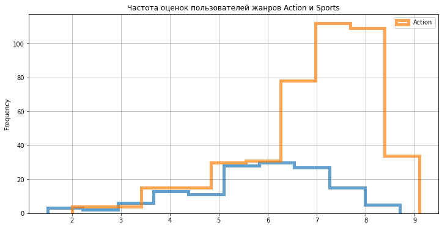

```python
# Гистограмма
ax = df_Sports.plot(kind='hist', y='user_score', histtype='step', \
                    bins=10, linewidth=5, alpha=0.7, label='Sports')
df_Action.plot(kind='hist', y='user_score', histtype='step', bins=10, linewidth=5, alpha=0.7, \
               label='Action', ax=ax, grid=True, legend=True, figsize=(12,6), \
               title='Частота оценок пользователей жанров Action и Sports');
```

Нулевая гипотеза: Средние пользовательские рейтинги жанров Action и Sports одинаковы.

Альтернативная гипотеза: Средние пользовательские рейтинги жанров Action и Sports различны (больше или меньше).

Зададим критический уровень статистической значимости 5%, если p-value окажется меньше него - отвергнем гипотезу. Пользователи исследуемых жанров явно из разных сегментов, показатель std выборок отличается, предыдущие исследования показали что жанры имеют разный рейтинг в разных регионах, поэтому параметр equal_var укажем False.

```python
alpha = .05
```

```python
results = st.ttest_ind(df_Action, df_Sports, equal_var = False)
print('p-значение:', results.pvalue)

if results.pvalue < alpha:
    print("Отвергаем нулевую гипотезу")
else:
    print("Не получилось отвергнуть нулевую гипотезу")
```

```
p-значение: 8.926417011727624e-14
Отвергаем нулевую гипотезу
```

### Вывод

Значение p-value показывает: вероятность случайно получить такое или большее различие очень мала, на это же указывает и большая разница в средних рейтингах пользователей по разным жанрам. Это явно слишком маленькая вероятность, чтобы делать вывод об одинаковых средних рейтингах. Наша гипотеза о том что средние пользовательские рейтинги жанров Action и Sports разные не отвергается.

## Общий вывод

**Перед проведением анализа данные были обработаны следующим образом:**

- названия столбцов приведены к нижнему регистру
- столбец с годом выпуска игры приведен к типу int32
- столбец с оценками пользователей приведен к типу float64
- Удалено 2 строки с отсутствующими полями name и genre
- Удалена 1 стрка - неполный дубликат
- Установлены значения-заглушки для пропущенных значений в столбцах оценки пользователей и оценки критиков
- Посчитаны суммарные продажи во всех регионах и записаны в отдельный столбец.

**Анализ данных показал что:**

**Закономерности, определяющие успешность игры:**

- Игра должна иметь версии для популярных платформ ( в 2016 году это XOne и PS4)
- Зависимости между продажами игры и оценками пользователей или критиков не выявлено, также пользовательские рейтинги разных жанров отличаются, поэтому не стоит ориентироваться на оценки.
- Более успешными будут игры жанров: Shooter, Action, Sports, Platform, Racing. Но если магазин ориентирован на покупателей из Японии, то в первую очередь будут успешны игры жанра Role-Playing.
- В зависимости от покупательской аудитории нужно ориентироваться на рейтинг ESRB: в Европе и Америкие успешны игры с рейтингом «M» («Mature») — «Для взрослых», в Японии - «E» («Everyone») — «Для всех» и «T» («Teen») — «Подросткам».